# Intro to Data Science - HW 5

##### Copyright 2021, Jeffrey Stanton, Jeffrey Saltz, and Jasmina Tacheva

```r
# Enter your name here:Pranav Sharma
```

### Attribution statement: (choose only one and delete the rest)

```r
# 1. I did this homework by myself, with help from the book and the professor.
#install.packages("maps")
##install.packages("mapproj")
#install.packages("ggmap")
library(maps)
library(mapproj)
library(ggmap)
#install.packages("ggplot2")
library(ggplot2)
```

us <- map_data(“state”) us$state_name <- tolower(us$region)

map <- ggplot(us, aes(map_id= state_name)) map <- map + aes(x=long, y=lat, group=group) + geom_polygon(fill = “white”, color = “black”) map <- map + expand_limits(x=us$long, y=us$lat) map <- map + coord_map() + ggtitle(“USA Map”) map

1.Add a comment for each line of code, explaining what that line of code does.

```r
?map_data
```

```
## starting httpd help server ... done
```

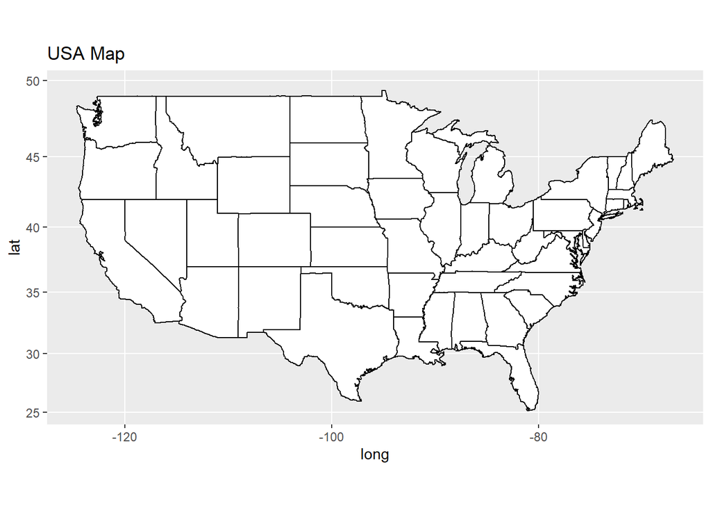

```r
# here map_data easily turns data from the maps package in to a dataframe suitable for plotting with ggplot2
us <- map_data("state")
#defining a new column or putting in the existing column value of region column of US.
us$state_name <- tolower(us$region)
# defining map plot with ggplot of us with aesthetics map_id
map <- ggplot(us, aes(map_id= state_name))
# adding conditions to your ggplot with aes(), x-axis-> longitude,y->latitude,group->group plus adding polygon plot with ggplot with function geom_polygon
map <- map + aes(x=long, y=lat, group=group) +
             geom_polygon(fill = "white", color = "black")
# Now we are Inputing the latitudes and longitudes of US

# the expand limits function expands the plot limits and the us$long and us$lat are the limiters set through x and y axis.
map <- map + expand_limits(x=us$long, y=us$lat)

# adding coord_map() projects the earth onto a 2d flat plane. With GGtitle you should be able to see the title on the map plot.
map <- map + coord_map() + ggtitle("USA Map")
map
```

2.The map you just created fills in the area of each state in white while outlining it with a thin black line. Use the fill= and color= commands inside the call to geom_polygon( ) to reverse the color scheme

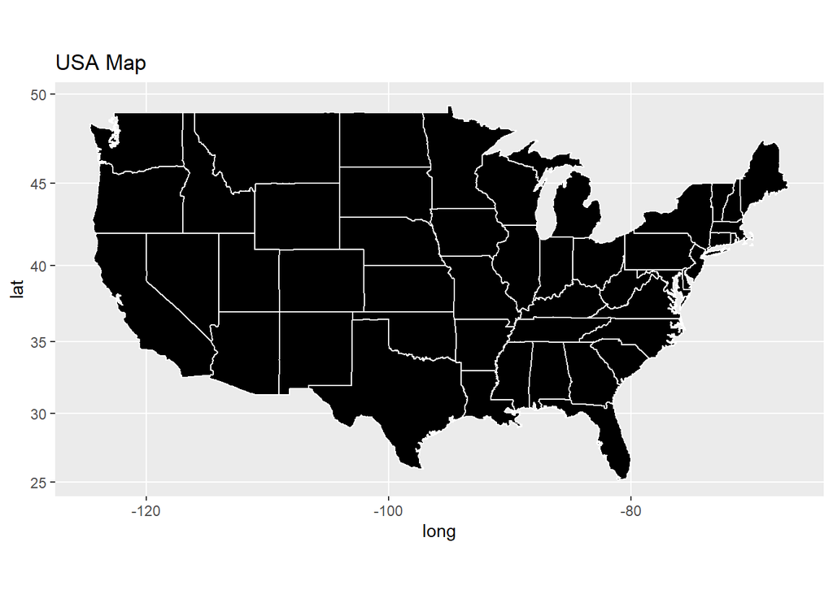

```r
map4 <- map + geom_polygon(fill="black",color="white")
map4
```

Now run the following code: ny_counties <- map_data(“county”,“new york”)

ggplot(ny_counties) + aes(long,lat, group=group) + geom_polygon(fill = “white”, color = “black”)

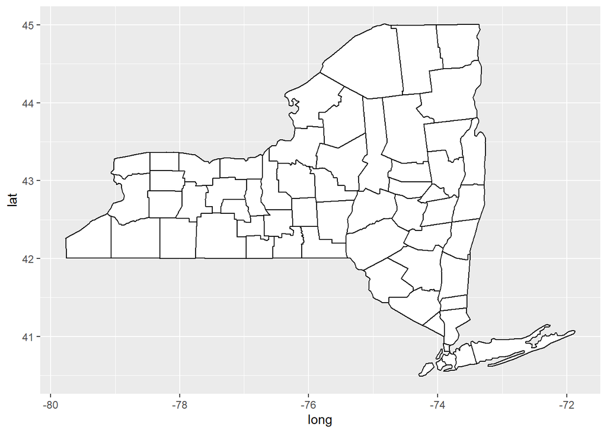

```r
ny_counties <- map_data("county","new york")

ny_counties3<- ggplot(ny_counties) + aes(long,lat, group=group) + geom_polygon(fill = "white", color = "black")
ny_counties3
```

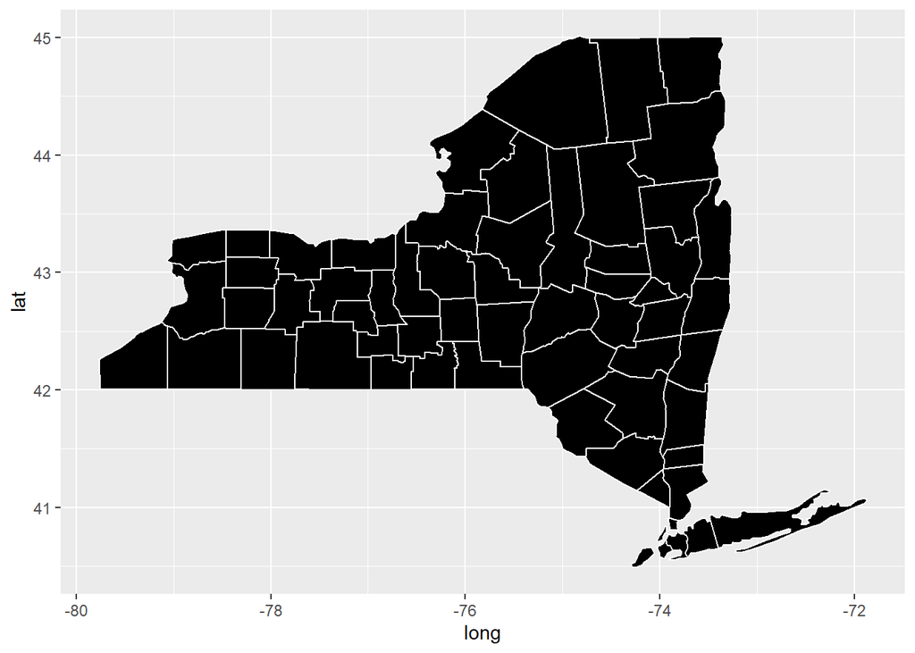

```r
ny_counties_3 = ny_counties3 + geom_polygon(fill="black",color="white" )
ny_counties_3
```

4.Run head(ny_counties) to verify how the county outline data looks.

```r
head(ny_counties)
```

```
##        long      lat group order   region subregion
## 1 -73.78550 42.46763     1     1 new york    albany
## 2 -74.25533 42.41034     1     2 new york    albany
## 3 -74.25533 42.41034     1     3 new york    albany
## 4 -74.27252 42.41607     1     4 new york    albany
## 5 -74.24960 42.46763     1     5 new york    albany
## 6 -74.22668 42.50774     1     6 new york    albany
```

5.Make a copy of your code from step 3 and add the following subcommand to your ggplot( ) call (don’t forget to put a plus sign after the geom_polygon( ) statement to tell R that you are continuing to build the command): coord_map(projection = “mercator”) In what way is the map different from the previous map. Be prepared to explain what a Mercator projection is.

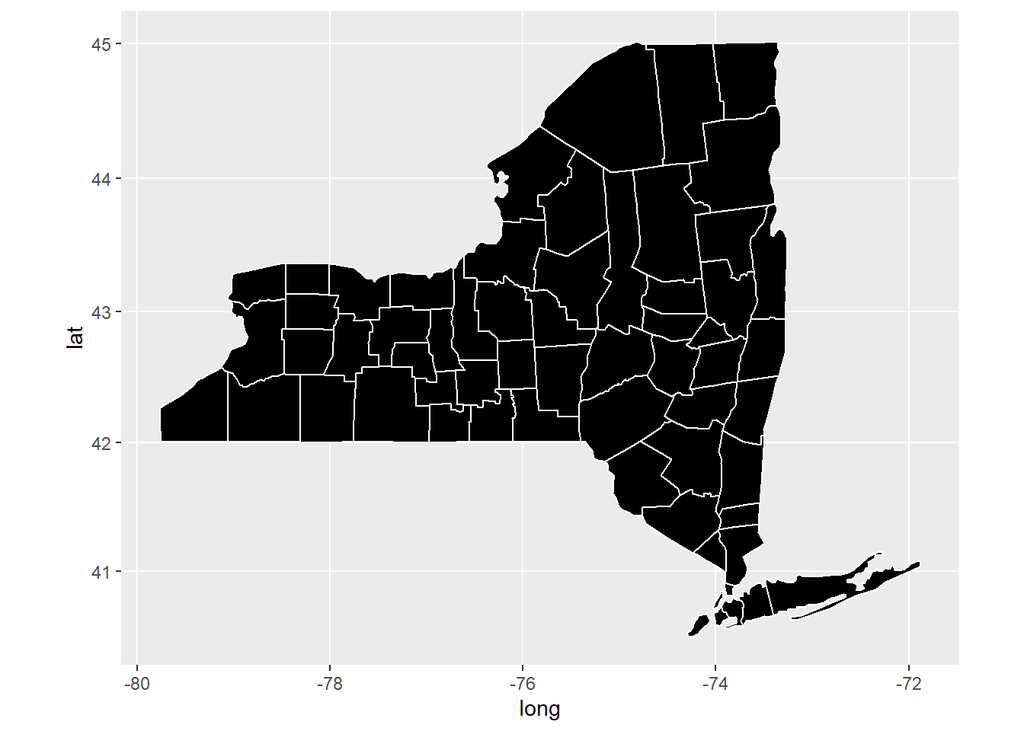

```r
# size gets smaller and focussed and cylindrical form. the ratio of latitude to longitude varies across the globe. Near equator the ratio is almost 1 but near the poles it tends towards infinity because length of 1 degree of longitude tends towards 0. For regions that span only a few degrees and are not too close to the poles, setting the aspect raio of plot to an approximate ratio of latitude/longitude is the mercator projection.
ny_counties_3 + coord_map(projection = "mercator")
```

6.Grab a copy of the nyData.csv data set from: https://intro-datascience.s3.us-east-2.amazonaws.com/nyData.csv Read that data set into R with read_csv(). This will require you have installed and libraried the readr package. The next step assumes that you have named the resulting data frame “nyData.

```r
#install.packages("tidyverse")
library(
  readr
)
nyData <-  read_csv('https://intro-datascience.s3.us-east-2.amazonaws.com/nyData.csv')
```

7.Next, merge your ny_counties data from the first set of questions with your new nyData data frame, with this code: mergeNY <- merge(ny_counties,nyData, all.x=TRUE,by.x=“subregion”,by.y=“county”)

```r
View(ny_counties)
View(nyData)
mergeNY <- merge(ny_counties,nyData,all.x=TRUE,by.x="subregion",by.y="county")
```

8.Run head(mergeNY) to verify how the merged data looks.

```r
head(mergeNY)
```

```
##   subregion      long      lat group order   region pop2010 pop2000 sqMiles
## 1    albany -73.78550 42.46763     1     1 new york  304204  294565   522.8
## 2    albany -74.25533 42.41034     1     2 new york  304204  294565   522.8
## 3    albany -74.25533 42.41034     1     3 new york  304204  294565   522.8
## 4    albany -74.27252 42.41607     1     4 new york  304204  294565   522.8
## 5    albany -74.24960 42.46763     1     5 new york  304204  294565   522.8
## 6    albany -74.22668 42.50774     1     6 new york  304204  294565   522.8
##   popDen
## 1 581.87
## 2 581.87
## 3 581.87
## 4 581.87
## 5 581.87
## 6 581.87
```

9.Now drive the fill color inside each county by adding the fill aesthetic inside of your geom_polygon( ) subcommand (fill based on the pop2000).

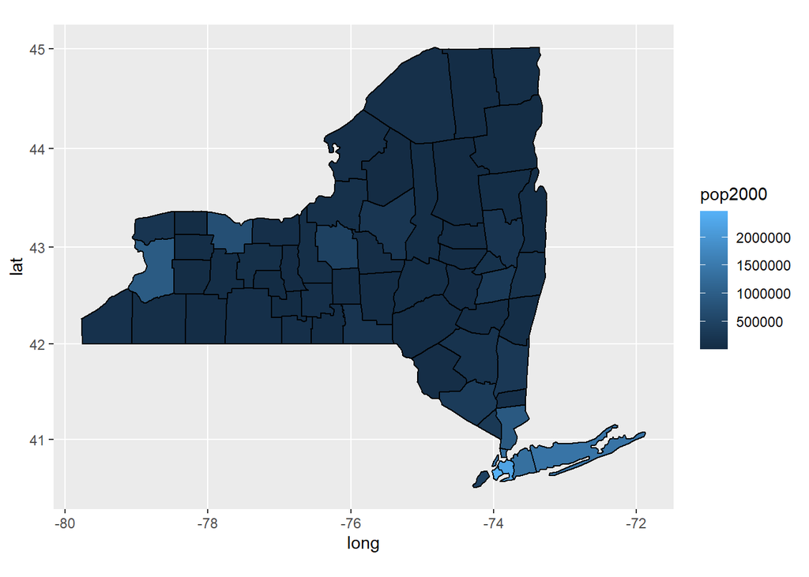

```r
ggplot(mergeNY) + aes(long,lat, group=group) + geom_polygon(aes(fill=pop2000),color="black") + coord_map(projection = "mercator")
```

10. Extra (not required): a. Read in the following JSON datasets: ‘https://gbfs.citibikenyc.com/gbfs/en/station_information.json’ ‘https://gbfs.citibikenyc.com/gbfs/en/station_status.json’ b. Merge the datasets, based on ‘station_id’ c. Clean the merged dataset to only include useful information For this work, you only need lat, lon and the number of bikes available d. Create a stamen map using ‘get_stamenmap()’ Have the limits of the map be defined by the lat and lot of the stations e. Show the stations, as points on the map. f. Show the number of bikes available as a color